# Naive Bayes Spam Filter

Nayan Saikia

April 3, 2016

Assignment is to determine if a given text is ‘ham’ or ‘spam’

We will begin by loading the libraries and the dataset. The original dataset was tab delimited. Although such a dataset can be loaded using separator as ‘’, it was giving problem in this case. Hence, the original dataset was converted to a .csv file to upload.

```r
#load libraries
library(tm)
```

```r
library(SnowballC)
library(e1071)
library(wordcloud)
#load dataset
hamspam <- read.csv("/home/awaz/Documents/UISCourses/DataScience/NaiveBayes/SMSSpamCollection.csv",stringsAsFactors = FALSE)
str(hamspam)
```

```
## 'data.frame':    4837 obs. of  2 variables:
##  $ Type: chr  "ham" "ham" "spam" "ham" ...
##  $ Text: chr  "Go until jurong point, crazy.. Available only in bugis n great world la e buffet... Cine there got amore wat..." "Ok lar... Joking wif u oni..." "Free entry in 2 a wkly comp to win FA Cup final tkts 21st May 2005. Text FA to 87121 to receive entry question(std txt rate)T&C"| __trun…
```

Convert the ‘type’ to a factor and the text to a corpus.

```r
#convert type to factor
hamspam$Type <- as.factor(hamspam$Type)
#convert the text portion to a corpus
hs_corpus <- VCorpus(VectorSource(hamspam$Text))
```

Perform the necessary cleaning of the corpus

```r
#Clean the corpus
hs_corpus_cln <- tm_map(hs_corpus, content_transformer(tolower))
hs_corpus_cln <- tm_map(hs_corpus_cln, removeNumbers)
hs_corpus_cln <- tm_map(hs_corpus_cln, removeWords, stopwords())
hs_corpus_cln <- tm_map(hs_corpus_cln, removePunctuation)
hs_corpus_cln <- tm_map(hs_corpus_cln, stemDocument)
hs_corpus_cln <- tm_map(hs_corpus_cln, stripWhitespace)
```

Lets see what a word cloud shows us:

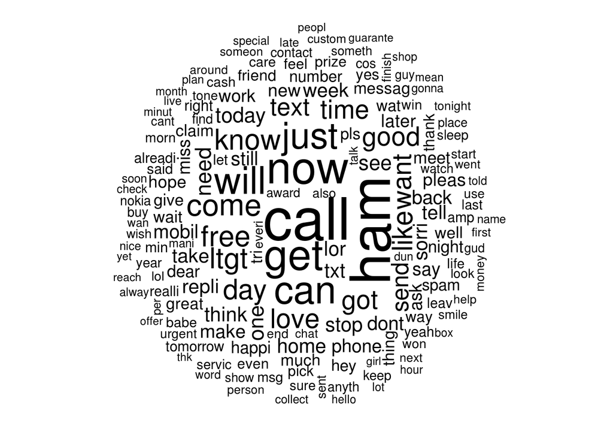

There still seems to be a lot of words that does not seem to convey a whole lot of meaning. The words ‘ham’ and ‘call’ seems to dominate. We will proceed to create a document term matrix. We will also remove any words occuring less than 5 times.

```r
#Create DTM
hs_DTM <- DocumentTermMatrix(hs_corpus_cln)
#Remove words occuring less than 5 times
freq_words <- findFreqTerms(hs_DTM, 5)
hs_DTM_freq <- hs_DTM[,freq_words]
```

Since Naive Bayes works on categorical data, we will convert the term counts to YES or NO. If term count is zero, it will be NO otherwise YES.

```r
#Convert counts to YES or NO
conv_counts <- function(x){x <- ifelse(x > 0, "YES", "NO")}
hs_DTM_cat <- apply(hs_DTM_freq, MARGIN = 2, conv_counts)
```

Normally, Naive Bayes works on a matrix. But to be on the safe side, converted the matrix to a data frame

```r
#convert it to a data frame
hs_df <- as.data.frame(hs_DTM_cat)
```

We will split the resulting data frame to a test and train set

```r
#split train and test
index <- 1:floor(nrow(hs_DTM)/3)
hs_train <- hs_df[-index,]
hs_test <- hs_df[index,]
hs_train_label <- hamspam$Type[-index]
hs_test_label <- hamspam$Type[index]
```

We will proceed to build the model and predict the test set

```r
#Build model
hs_model <- naiveBayes(hs_train,hs_train_label)
hs_test_pred <- predict(hs_model,hs_test)
```

The cross table below shows that the model has an error rate of approx. 2%. For a spam filter, reducing false positive is more important. In this case, false positive error rate is approx. 1.6%.

```r
#Cross table
library(gmodels)
CrossTable(hs_test_pred,hs_test_label,prop.chisq = FALSE,prop.t = FALSE,dnn=c('predicted','actual'))
```

```
##
##
##    Cell Contents
## |-------------------------|
## |                       N |
## |           N / Row Total |
## |           N / Col Total |
## |-------------------------|
##
##
## Total Observations in Table:  1612
##
##
##              | actual
##    predicted |       ham |      spam | Row Total |
## -------------|-----------|-----------|-----------|
##          ham |      1376 |        22 |      1398 |
##              |     0.984 |     0.016 |     0.867 |
##              |     0.991 |     0.098 |           |
## -------------|-----------|-----------|-----------|
##         spam |        12 |       202 |       214 |
##              |     0.056 |     0.944 |     0.133 |
##              |     0.009 |     0.902 |           |
## -------------|-----------|-----------|-----------|
## Column Total |      1388 |       224 |      1612 |
##              |     0.861 |     0.139 |           |
## -------------|-----------|-----------|-----------|
##
##
```

To find ROC and AUC, we will have to first convert ‘ham’ and ‘spam’ to 1 and 0. ‘ham’ is considered 1, while ‘spam’ is considered ‘0’.

```r
#ROC
library(ROCR)
#In order for ROC to function, need to convert ham and spam to 1 and 0
conv_num <- function(x){x <- ifelse(x=="ham",1,0)}
hs_pred_ROC <- sapply(hs_test_pred, conv_num)
hs_label_ROC <- sapply(hs_test_label, conv_num)
pred <- prediction(hs_pred_ROC,hs_label_ROC)
perf <- performance(pred, measure = "tpr", x.measure = "fpr")
```

The peformance plot is as below:

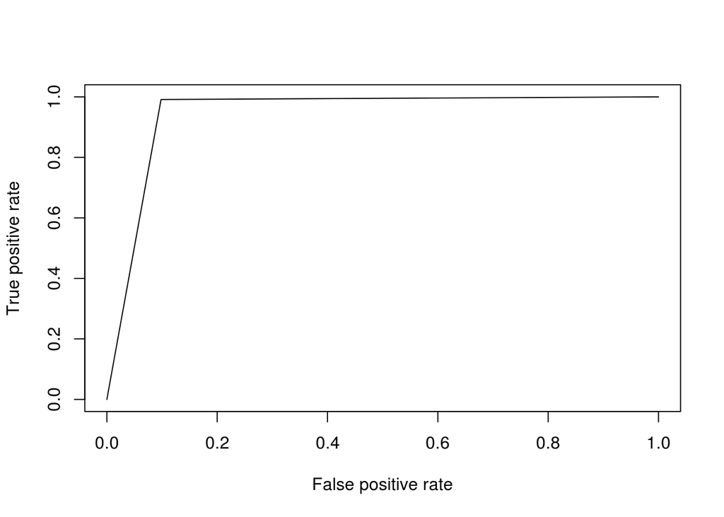

Finally, we will calculate AUC

```r
auc <- performance(pred,measure = "auc")@y.values[[1]]
```

The AUC value is 0.9465701 This model performed pretty good. Laplacian correction is added to while calculating the probabilities of the independent attributes just in case for some attribute the probability turns out to be zero. Adding, say 1, to each occurance of an attribute should have practically no impact to the probability distribution of the attribute. Instead, it will prevent the probability of a certain attribute to be zero.

```r
#Try with a small laplacian correction
hs_model_lap <- naiveBayes(hs_train,hs_train_label,laplace = 1)
hs_test_pred_lap <- predict(hs_model_lap,hs_test)
```

From the cross table below, we see that with laplace correction, the model perfomed slightly worse. The laplace correction can be adjusted to see if makes a difference, but we will not attempt here.

```
##
##
##    Cell Contents
## |-------------------------|
## |                       N |
## |           N / Row Total |
## |           N / Col Total |
## |-------------------------|
##
##
## Total Observations in Table:  1612
##
##
##              | actual
##    predicted |       ham |      spam | Row Total |
## -------------|-----------|-----------|-----------|
##          ham |      1377 |        27 |      1404 |
##              |     0.981 |     0.019 |     0.871 |
##              |     0.992 |     0.121 |           |
## -------------|-----------|-----------|-----------|
##         spam |        11 |       197 |       208 |
##              |     0.053 |     0.947 |     0.129 |
##              |     0.008 |     0.879 |           |
## -------------|-----------|-----------|-----------|
## Column Total |      1388 |       224 |      1612 |
##              |     0.861 |     0.139 |           |
## -------------|-----------|-----------|-----------|
##
##
```